# A3: More on Graphs

# Setup

#### Using R Markdown

For this assignment we are going to use R Markdown (rather than a script file). We will go into the details of R Markdown in the coming weeks. For now, we are just going to plug in R code where appropriate. This assignment will guide you along the way.

**Note:** In **R Markdown** files, text that is black (white background) should be standard text and will return standard text. Text that is in “R chunks” (background shaded grey) should be R code and will produce the output for that code.

## Setting up for Assignment

### Step 1:

**Action:** Download the **A3_MoreOnGraphs_Template.Rmd** file from **[Canvas](https://clemson.instructure.com/courses/237270/files/23503669/download?download_frd=1)** or the **[Box Folder](https://clemson.box.com/s/mh6fx9wmasiqxxeufl7kmt73lo2rjdgt)** to your computer.

### Step 2:

**Action:** Copy the **A3_MoreOnGraphs_Template.Rmd** file from wherever you downloaded the file (typically the Downloads folder) into your project directory (folder) for this lab. You don’t want to be editing the file in your downloads folder.

**This is important - DON’T SKIP THIS STEP**

### Step 3:

**Action:** Navigate to your project folder and double click on the .Rmd file. This will open the **A3_MoreOnGraphs_Template.Rmd** in RStudio.

**Note:** Double check that you are in your current Project by checking the name of the project in the upper left hand corner of RStudio.

### Step 4:

**Action:** At the top of the file (3rd line down) change the text **YOUR NAME HERE** to be your name. Be sure you keep the quotation marks.

### Step 5:

**Action:** In the tool bar directly at the top of the .Rmd file click the dropdown arrow next to the Settings Wheel . Select **Preview in Viewer Pane**

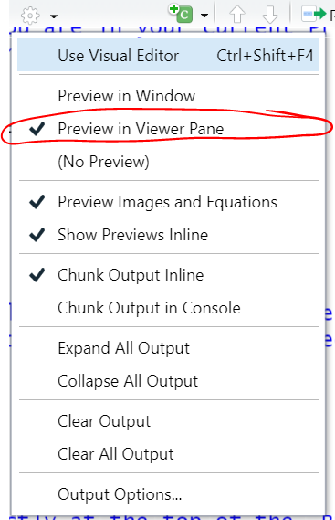

**Note:**

All actions below (in blue boxes) should be done in the **A3_MoreOnGraphs_Template.Rmd** file. You can rename the file if you would like.

#### Loading Packages in .Rmd file

Any packages that you have installed in RStudio you may use in your .Rmd file. However, you should note that if your desired package is loaded (checked) in RStudio that does not mean it is loaded in your .Rmd file. It is good practice, while working in R Markdown to load packages BOTH in RStudio and in your .Rmd file.

A typical practice for loading packages in R Markdown is to do so in one place near the top of the file.

**Action:** In your **A3_MoreOnGraphs_Template.Rmd** file, navigate to the R code chunk that looks like the following…

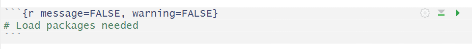

Under the comment that says “Load packages needed” load (using the library function) the `tidyverse` package.

# Terminology

### Number of Variables Involved

- **Univariate data analysis** - distribution of single variable
- **Bivariate data analysis** - relationship between two variables
- **Multivariate data analysis** - relationship between many variables at once, usually focusing on the relationship between two while conditioning for others

### Types of Variables

- **Numerical** variables can be classified as **continuous** or **discrete** based on whether or not the variable can take on an infinite number of values or only non-negative whole numbers, respectively.
- If the variable is **categorical**, we can determine if it is **ordinal** based on whether or not the levels have a natural ordering.

# Data for this assignment: Lending Club

[figure not shown]

- Thousands of loans made through the Lending Club, which is a platform that allows individuals to lend to other individuals
- Not all loans are created equal – ease of getting a loan depends on (apparent) ability to pay back the loan
- Data includes loans made, these are not loan applications
- Data comes from the `openintro` package.

**Action:**

- Install and Load the `openintro` package **in RStudio**.
- Load `openintro` package in .Rmd file right below where you loaded the `tidyverse` package.

## Quick Look at the data

Looking at the full dataset

```r
glimpse(loans_full_schema)
```

```
Rows: 10,000
Columns: 55
$ emp_title                        <chr> "global config engineer ", "warehouse…
$ emp_length                       <dbl> 3, 10, 3, 1, 10, NA, 10, 10, 10, 3, 1…
$ state                            <fct> NJ, HI, WI, PA, CA, KY, MI, AZ, NV, I…
$ homeownership                    <fct> MORTGAGE, RENT, RENT, RENT, RENT, OWN…
$ annual_income                    <dbl> 90000, 40000, 40000, 30000, 35000, 34…
$ verified_income                  <fct> Verified, Not Verified, Source Verifi…
$ debt_to_income                   <dbl> 18.01, 5.04, 21.15, 10.16, 57.96, 6.4…
$ annual_income_joint              <dbl> NA, NA, NA, NA, 57000, NA, 155000, NA…
$ verification_income_joint        <fct> , , , , Verified, , Not Verified, , ,…
$ debt_to_income_joint             <dbl> NA, NA, NA, NA, 37.66, NA, 13.12, NA,…
$ delinq_2y                        <int> 0, 0, 0, 0, 0, 1, 0, 1, 1, 0, 0, 0, 0…
$ months_since_last_delinq         <int> 38, NA, 28, NA, NA, 3, NA, 19, 18, NA…
$ earliest_credit_line             <dbl> 2001, 1996, 2006, 2007, 2008, 1990, 2…
```

[output cut: 42 more lines]

Let’s look at a subset of this data by creating a smaller dataset named `loans`.

```r
loans <- loans_full_schema %>%
  select(loan_amount, interest_rate, term, grade,
         state, annual_income, homeownership, debt_to_income)
glimpse(loans)
```

```
Rows: 10,000
Columns: 8
$ loan_amount    <int> 28000, 5000, 2000, 21600, 23000, 5000, 24000, 20000, 20…
$ interest_rate  <dbl> 14.07, 12.61, 17.09, 6.72, 14.07, 6.72, 13.59, 11.99, 1…
$ term           <dbl> 60, 36, 36, 36, 36, 36, 60, 60, 36, 36, 60, 60, 36, 60,…
$ grade          <fct> C, C, D, A, C, A, C, B, C, A, C, B, C, B, D, D, D, F, E…
$ state          <fct> NJ, HI, WI, PA, CA, KY, MI, AZ, NV, IL, IL, FL, SC, CO,…
$ annual_income  <dbl> 90000, 40000, 40000, 30000, 35000, 34000, 35000, 110000…
$ homeownership  <fct> MORTGAGE, RENT, RENT, RENT, RENT, OWN, MORTGAGE, MORTGA…
$ debt_to_income <dbl> 18.01, 5.04, 21.15, 10.16, 57.96, 6.46, 23.66, 16.19, 3…
```

**Action:**

Create this condensed dataframe (**loans**) in your **A3_MoreOnGraphs_Template.Rmd** file by copying and pasting the code above that creates the `loans` dataframe. Put your code in the appropriate location (shown in image below) in your R Markdown template (`.Rmd` file).

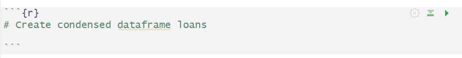

Below is a table of the descriptions of the variables in the `loans` dataframe.

| variable | description |
| --- | --- |
| `loan_amount` | Amount of the loan received, in US dollars |
| `interest_rate` | Interest rate on the loan, in an annual percentage |
| `term` | The length of the loan, which is always set as a whole number of months |
| `grade` | Loan grade, which takes a values A through G and represents the quality of the loan and its likelihood of being repaid |
| `state` | US state where the borrower resides |
| `annual_income` | Borrower’s annual income, including any second income, in US dollars |
| `homeownership` | Indicates whether the person owns, owns but has a mortgage, or rents |
| `debt_to_income` | Debt-to-income ratio |

Let’s look at the types of each of these variables. The type of variable will help us determine how we will analyze them.

# Variable types

The types can be viewed visually using the `vis_dat` function in the `visdat` package. Notice the difference in the function name and the package name.

**Action:**

- Install and Load the `visdat` package **in RStudio**.
- Load `visdat` package in .Rmd file right below where you loaded the `tidyverse` and `openintro` packages

Using the `vis_dat` function from the `visdat` package we can see a visual of the types of variables in the `loans` dataframe.

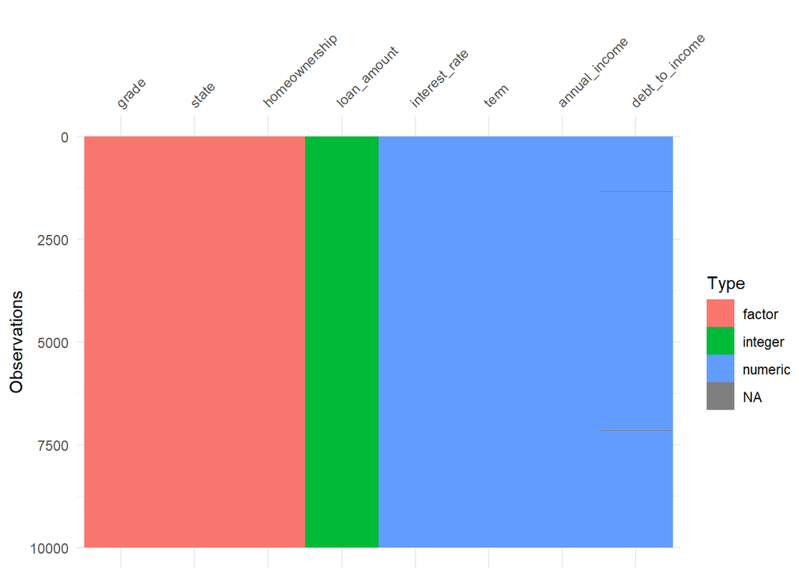

```r
vis_dat(loans)
```

**Action:** Create this visual in your **A3_MoreOnGraphs_Template.Rmd** file by copying and pasting the code above. Put the code in the appropriate location (shown in image below) in your R Markdown template (`.Rmd` file).

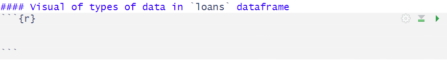

Be sure to paste/type your code in between the backtick lines (within the grey box)

The types of the variables in table form are as follows:

| variable | type |
| --- | --- |
| `loan_amount` | numerical, continuous |
| `interest_rate` | numerical, continuous |
| `term` | numerical, discrete |
| `grade` | categorical, ordinal |
| `state` | categorical, not ordinal |
| `annual_income` | numerical, continuous |
| `homeownership` | categorical, not ordinal |
| `debt_to_income` | numerical, continuous |

# Knitting your .Rmd file

The point of writing your code in a R Markdown file, rather than a script, is so that R Markdown will produce a document/report (html, pdf, or word) of your code and the output. This is easier for reporting purposes for your records and for class purposes it is easier for me to grade than a script.

You may execute individual code chunks using the green arrow in the upper right hand corner of the code chunk.

Now that you have written some code in your R Markdown template, you should see the output document that you are creating.

In order for you to see ALL the output of the r code chunks you will need to “Knit” the .Rmd document. To “Knit” a document click on the Knit icon in the toolbar at the top of the .Rmd file.

**Action:**

Click on the Knit icon in the toolbar at the top of the .Rmd file.

You should see a document appear in your viewer pane in RStudio. Look what you can do and its only Module 3!.

Continue to knit your document as you continue to add to the template file.

# Visualizing Numerical Data

## Describing the distribution of a variable

For any single numerical variable a researcher should report on the center, shape, and spread (variability) of the variable distribution. The researcher should also mention any unusual features in the distribution.

- shape:
  - skewness: right-skewed, left-skewed, symmetric (skew is to the side of the longer tail)
  - modality: unimodal, bimodal, multimodal, uniform
- center: mean (mean), median (median), mode (not always useful)
- spread: range (range), standard deviation (sd), inter-quartile range (IQR)
- unusual observations (gaps, outliers, etc.)

For now we are going to focus on shape. We will focus on the other parts in the next section.

Some typical “shapes” of data distributions are

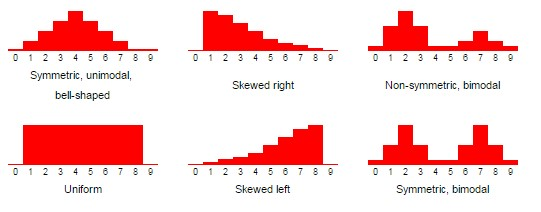

[Source: https://math.oxford.emory.edu/site/math117/shapeCenterAndSpread/](https://math.oxford.emory.edu/site/math117/shapeCenterAndSpread/)

## Histograms

Let’s first look at the numerical variable `loan_amount`. The code below generates a histogram of `loan_amount`.

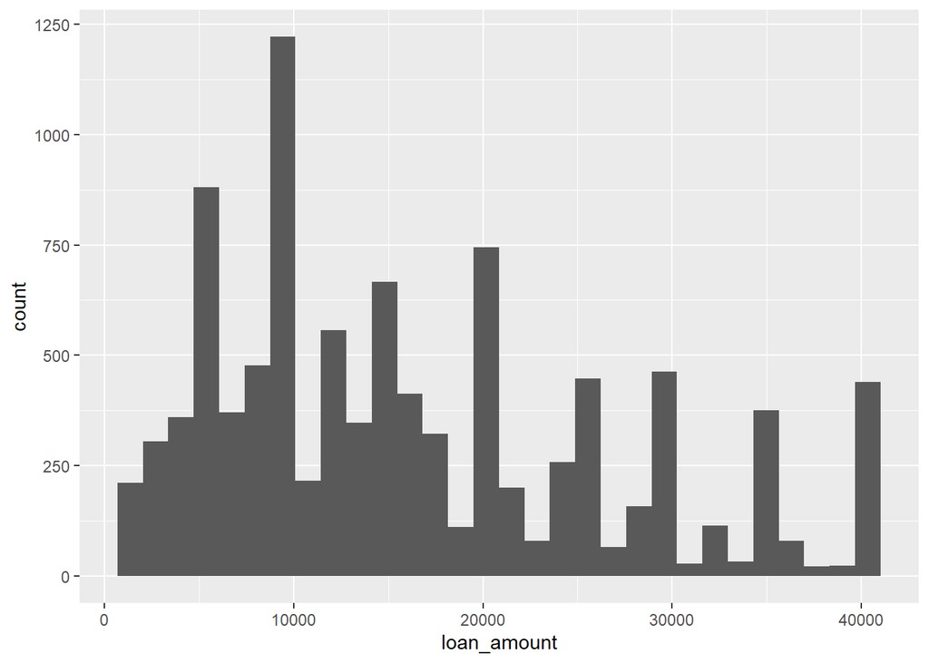

```r
ggplot(loans, aes(x = loan_amount)) +
  geom_histogram()
```

### Changing the bin size of a histogram

For histograms it may depend on the binwidth as to how well you can determine the shape of the data. When you are looking at shape you want to determine an overall general trend.

#### Binwidth = 1000

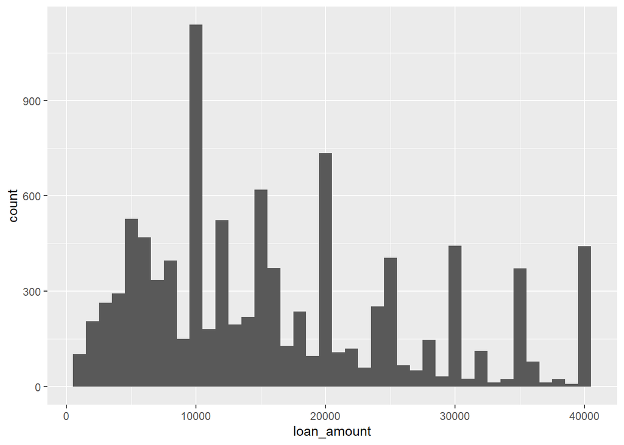

```r
ggplot(loans, aes(x = loan_amount)) +
  geom_histogram(binwidth = 1000)
```

Setting a binwidth of 1000 in the context of loan_amount means that each vertical bar has a width of $1000. The above histogram is too detailed to determine an overall general trend.

#### Binwidth = 5000

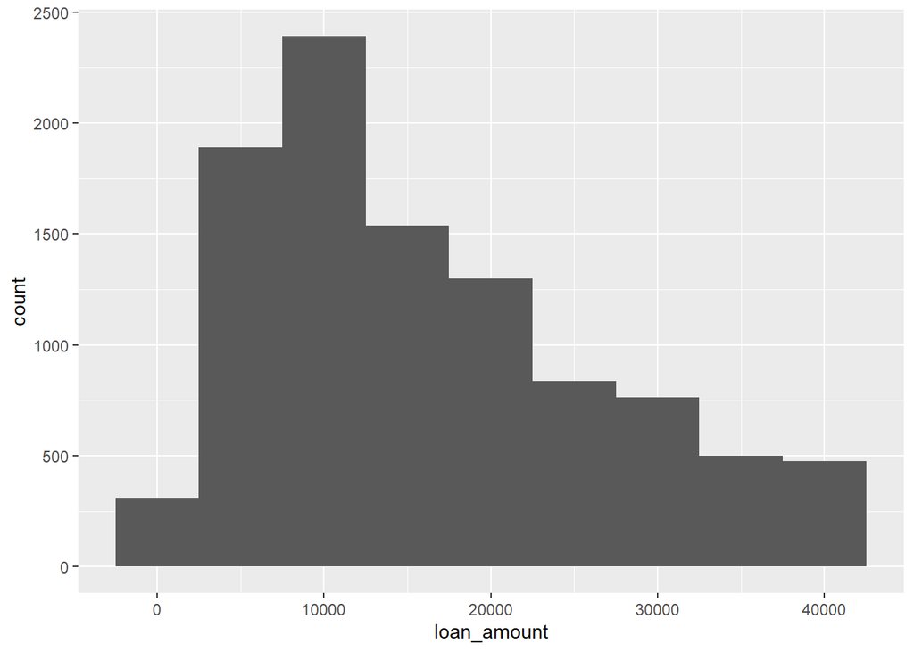

```r
ggplot(loans, aes(x = loan_amount)) +
  geom_histogram(binwidth = 5000)
```

The above histogram can help determine more of a general trend.

#### Binwidth = 20000

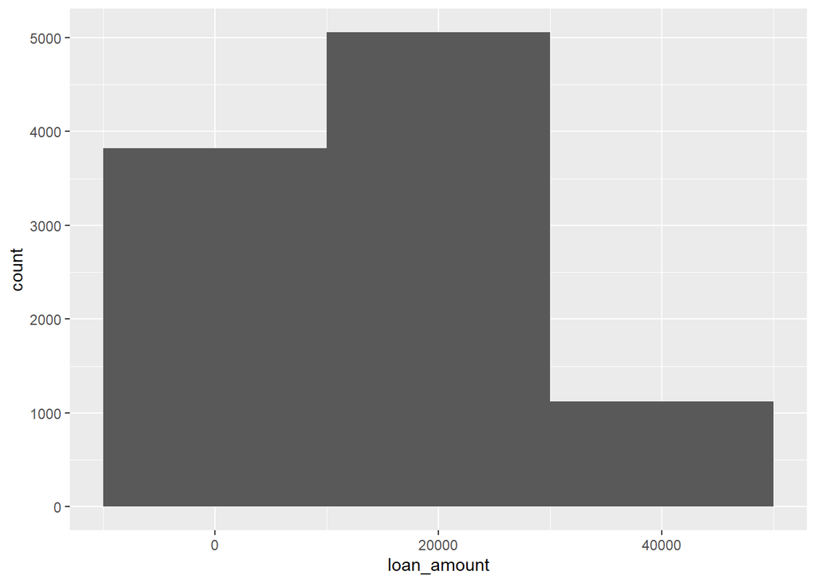

```r
ggplot(loans, aes(x = loan_amount)) +
  geom_histogram(binwidth = 20000)
```

**Based on the histogram with binwidth = 5000, the distribution of `loan_amount` is unimodal and right skewed.**

### Customizing Histogram with labels

Graphs and plots should provide appropriate titles and axis labels.

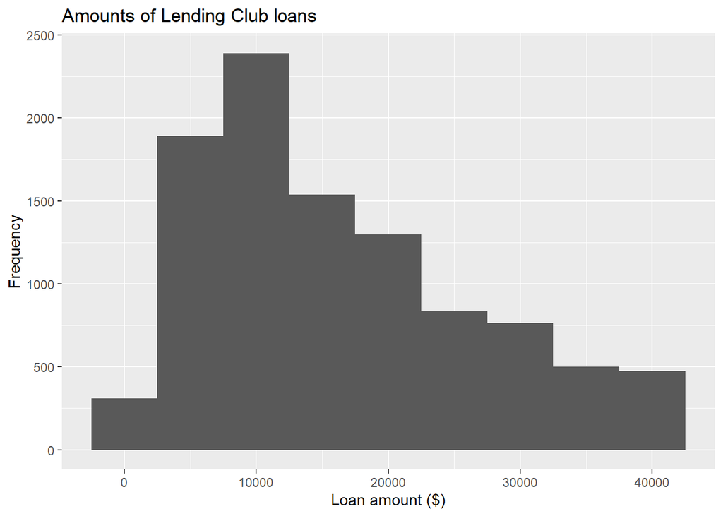

```r
ggplot(loans, aes(x = loan_amount)) +
  geom_histogram(binwidth = 5000) +
  labs(
    x = "Loan amount ($)",
    y = "Frequency",
    title = "Amounts of Lending Club loans"
  )
```

**Action:**

Using the `loans` dataframe create a histogram for **`interest_rate`**. The histogram should have an appropriate amount of bins. (Note: the number of bins for `loan_amount` may not be appropriate for `interest_rate`, these 2 variables are measured on different scales) Be sure to provide an apprppriate title and axis labels. Put your code in the appropriate location (seen in image below) in your R Markdown template (`.Rmd` file).

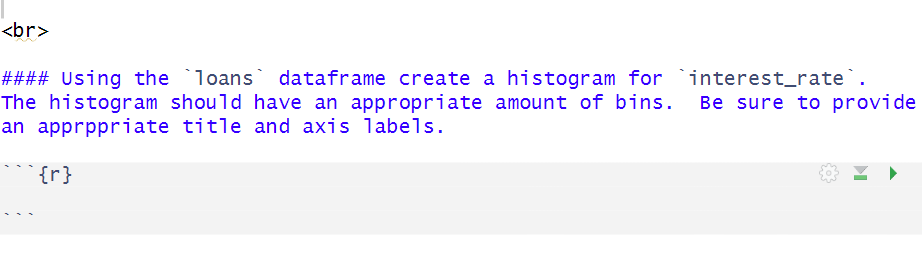

**Action:**

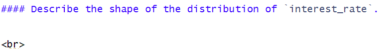

### Change Color of histogram

For a histogram, if we use the argument `color` this will add a color on the border of the bars. Notice the name of the color is in quotations.

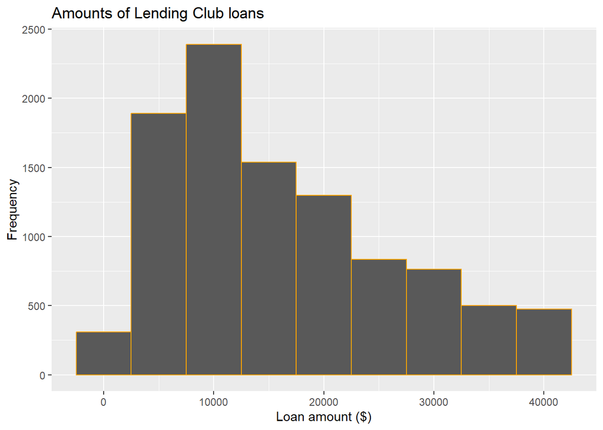

```r
ggplot(loans, aes(x = loan_amount)) +
  geom_histogram(binwidth = 5000, color="orange") +
  labs(
    x = "Loan amount ($)",
    y = "Frequency",
    title = "Amounts of Lending Club loans"
  )
```

For a histogram, if we use the argument `fill` this will fill the bars with a color.

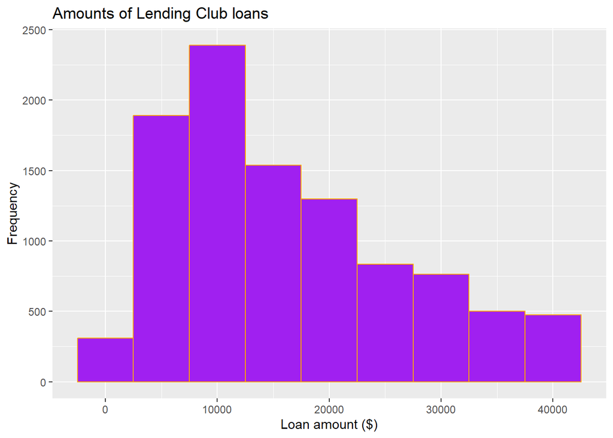

```r
ggplot(loans, aes(x = loan_amount)) +
  geom_histogram(binwidth = 5000, color="orange", fill="purple") +
  labs(
    x = "Loan amount ($)",
    y = "Frequency",
    title = "Amounts of Lending Club loans"
  )
```

### Fill histogram with categorical variable

It is possible to break down numerical graphs by a categorical variable in order to compare groups.

Adding the `fill` aesthetic shows the different categories. Adding `alpha=0.5` within the geom_histogram function gives the shaded areas of the categories a little bit (50%) of transparency.

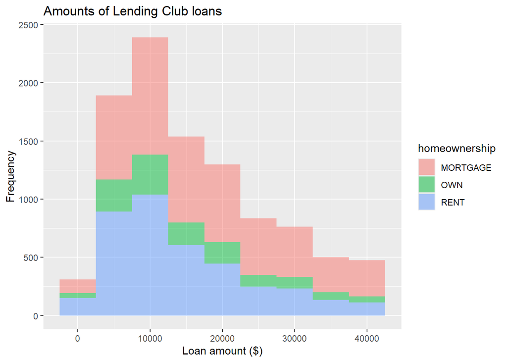

```r
ggplot(loans, aes(x = loan_amount,
                  fill = homeownership)) +
  geom_histogram(binwidth = 5000, alpha=0.5) +
  labs(
    x = "Loan amount ($)",
    y = "Frequency",
    title = "Amounts of Lending Club loans"
  )
```

### Facet with a categorical variable

Using the `facet` function

- will provide Smaller plots that display different subsets of the data
- is useful for exploring conditional relationships and large data

Below is the code for creating a histogram of the variable `loan_amount` with a separate graph for each type of `homeownership`. The `nrow` argument gives the number of rows wanted in the output.

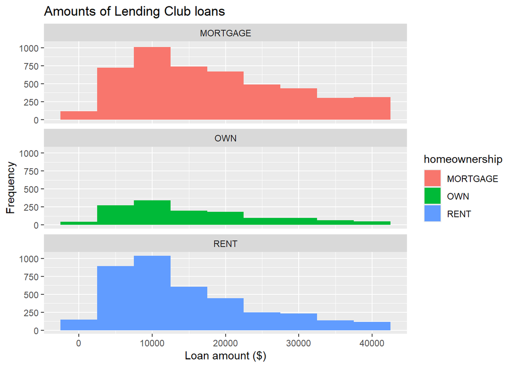

```r
ggplot(loans, aes(x = loan_amount, fill = homeownership)) +
  geom_histogram(binwidth = 5000) +
  labs(
    x = "Loan amount ($)",
    y = "Frequency",
    title = "Amounts of Lending Club loans"
  ) +
  facet_wrap(~ homeownership, nrow = 3)
```

**Note:** You can also facet based on two categorical variables by using code such as

`facet_wrap(A~B)` versus `facet_wrap(~B)`

In addition to the `facet_wrap` function you can use the `facet_grid` function.

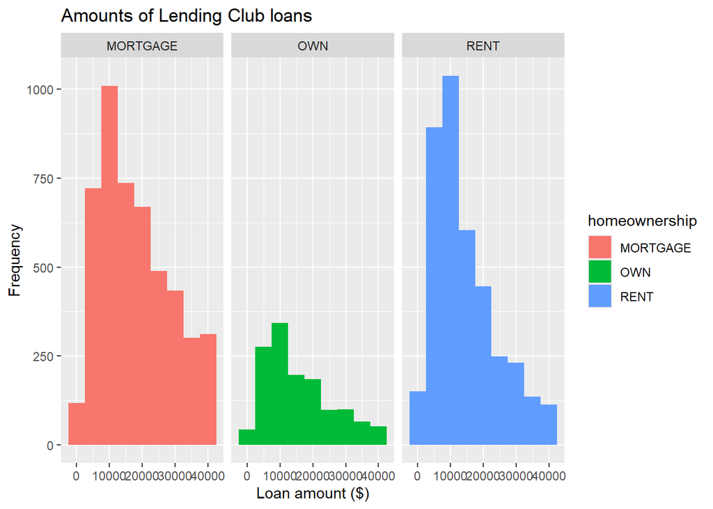

```r
ggplot(loans, aes(x = loan_amount, fill = homeownership)) +
  geom_histogram(binwidth = 5000) +
  labs(
    x = "Loan amount ($)",
    y = "Frequency",
    title = "Amounts of Lending Club loans"
  ) +
  facet_grid(~ homeownership)
```

**Action:**

Using the `loans` dataframe, create a facet histogram (using `facet_wrap` or `facet_wrap`) of `interest_rate` with a separate graph for each `grade`.Put your code in the appropriate location (see image below) in your R Markdown template (`.Rmd` file).

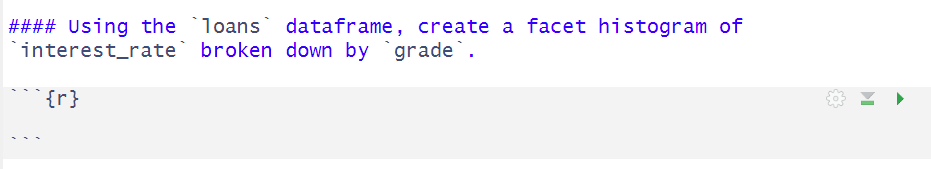

## Density Plot

Density plots use a kernel density estimate to show the probability density function of the variable. It is a smoothed version of the histogram and is used in the same concept.<sup>2</sup>

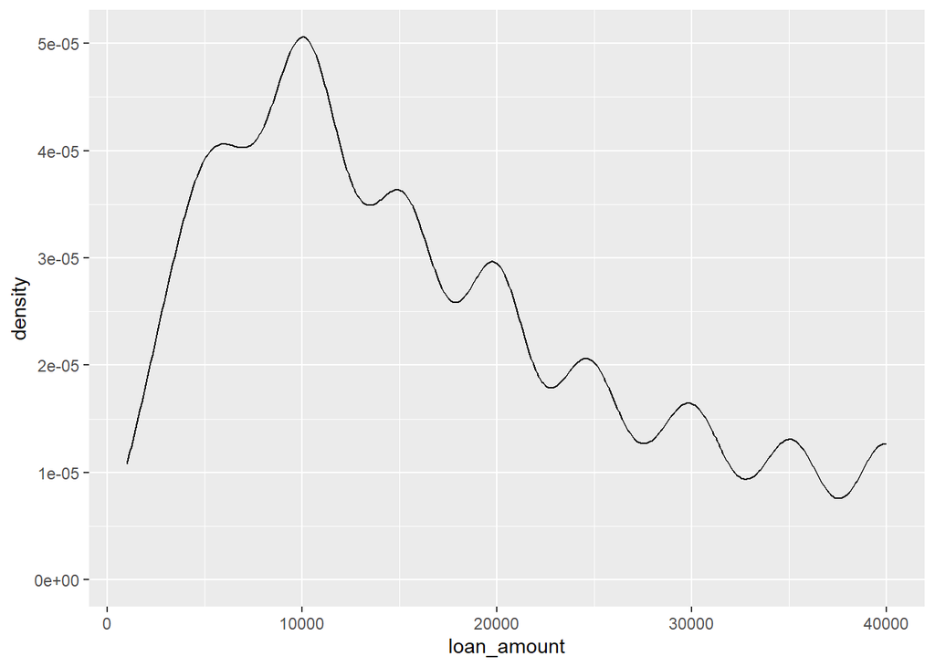

```r
ggplot(loans, aes(x = loan_amount)) +
  geom_density()
```

### Desity plots and adjusting banwidth

The banwidth of a density plot will determine how smooth the density curve is. Just like with histograms, the bandwidth can be adjusted to help determine an overal trend of the data.

#### adjust = 0.5

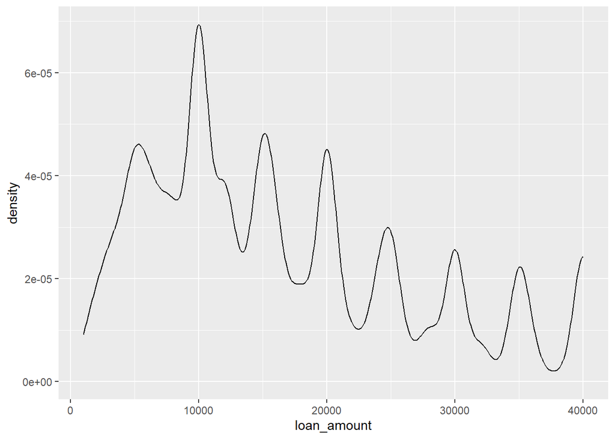

```r
ggplot(loans, aes(x = loan_amount)) +
  geom_density(adjust = 0.5)
```

#### adjust = 1

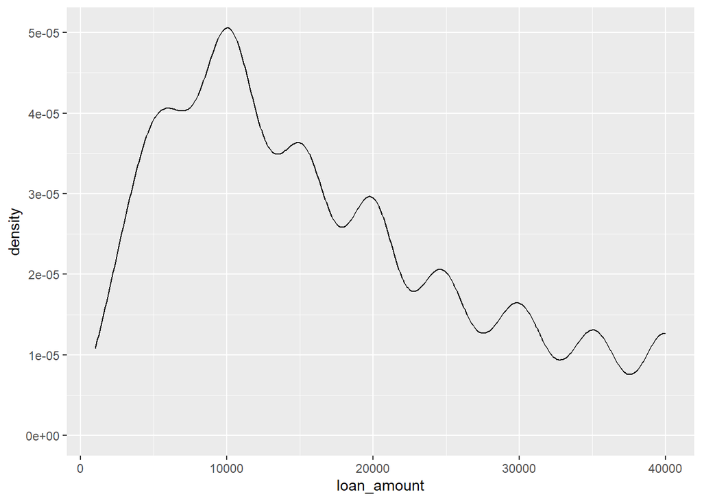

```r
ggplot(loans, aes(x = loan_amount)) +
  geom_density(adjust = 1)
```

#### adjust = 2

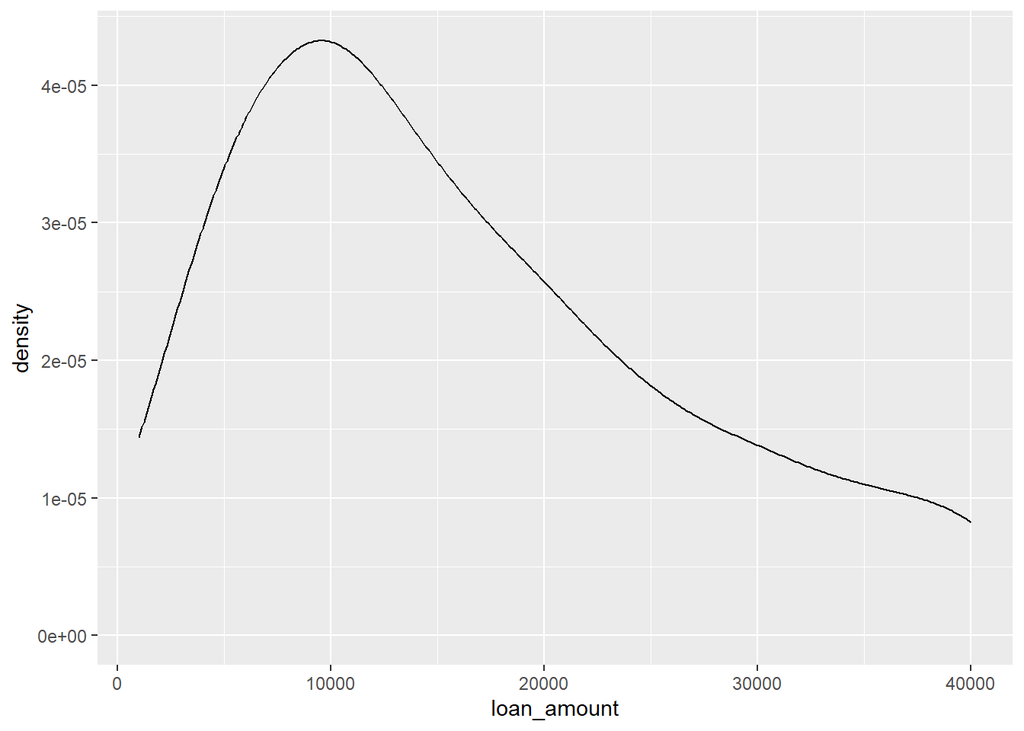

```r
ggplot(loans, aes(x = loan_amount)) +
  geom_density(adjust = 2)
```

### Customizing Density Plots

#### Adding title and axis labels.

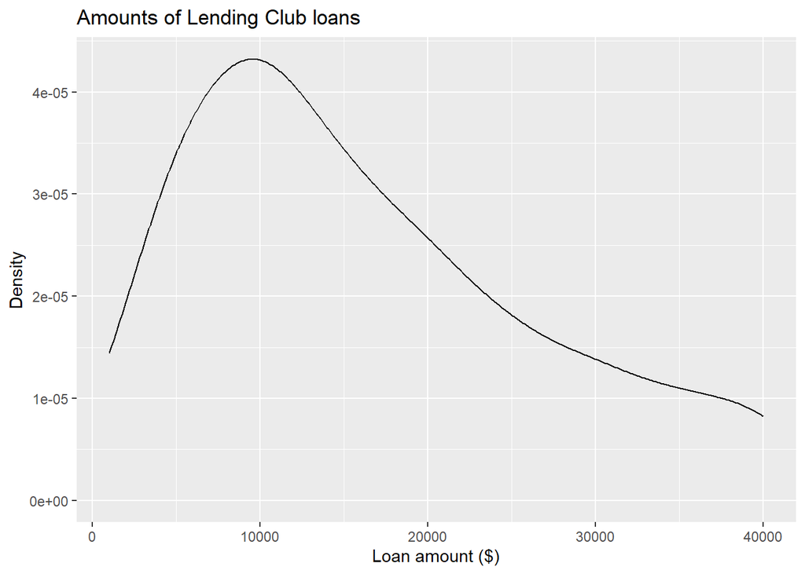

```r
ggplot(loans, aes(x = loan_amount)) +
  geom_density(adjust = 2) +
  labs(
    x = "Loan amount ($)",
    y = "Density",
    title = "Amounts of Lending Club loans"
  )
```

#### Changing color

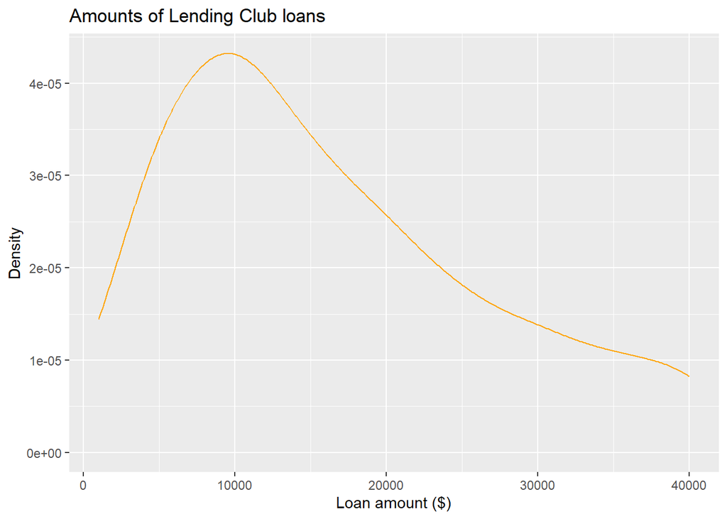

```r
ggplot(loans, aes(x = loan_amount)) +
  geom_density(adjust = 2, color="orange") +
  labs(
    x = "Loan amount ($)",
    y = "Density",
    title = "Amounts of Lending Club loans"
  )
```

### Adding a Categorical Variable

Just like with histograms, we can provide more detail about a density plot by separating by a categorical variable using the `fill` argument. As with histograms the `alpha` argument gives the shaded areas of the categories a little bit of transparency.

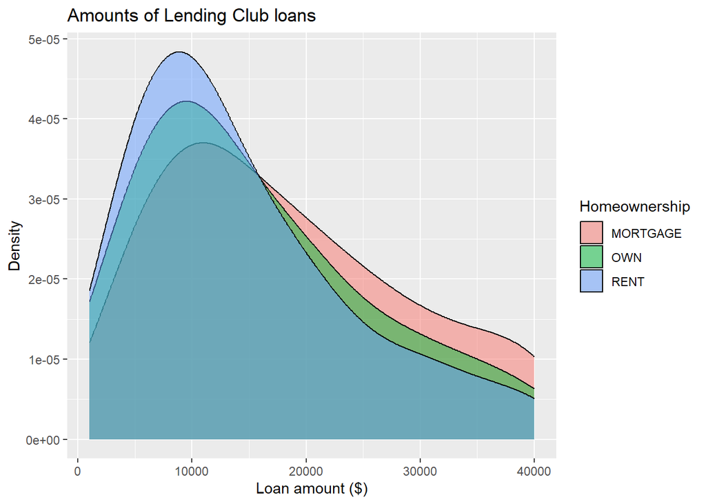

```r
ggplot(loans, aes(x = loan_amount,
                  fill = homeownership)) +
  geom_density(adjust = 2,
               alpha = 0.5) +
  labs(
    x = "Loan amount ($)",
    y = "Density",
    title = "Amounts of Lending Club loans",
    fill = "Homeownership"
  )
```

**Action:**

Using the `loans` dataframe, create a density plot of `interest_rate` separated by `grade`. (Note: You will need to change the value of the `adjust` argument to fit the data to the graph - I used 5 as an `adjust` argument) Use an appropriate adjustment value. Use appropriate titles and labels. Put your code in the appropriate location (see image below) in your R Markdown template (`.Rmd` file).

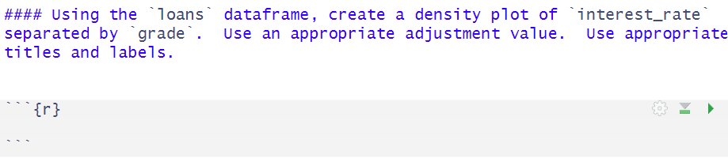

**Action:**

Do you notice anything unusual about this graph? Explain in the appropriate location in the appropriate location (see image below) in your R Markdown template. Note: this is text not R code.

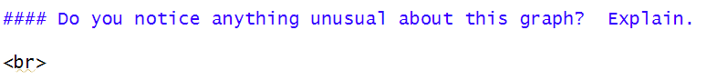

## Boxplots

A boxplot gives a nice summary of one or several numeric variables. The line that divides the box into 2 parts represents the median of the data. The end of the box shows the upper and lower quartiles. The extreme lines show the highest and lowest value excluding outliers.<sup>2</sup>

A boxplot is a graph that gives you a good indication of how the values in the data are spread out. Although boxplots may seem primitive in comparison to a histogram or density plot, they have the advantage of taking up less space, which is useful when comparing distributions between many groups or datasets. <sup>3</sup>

### Creating Boxplots

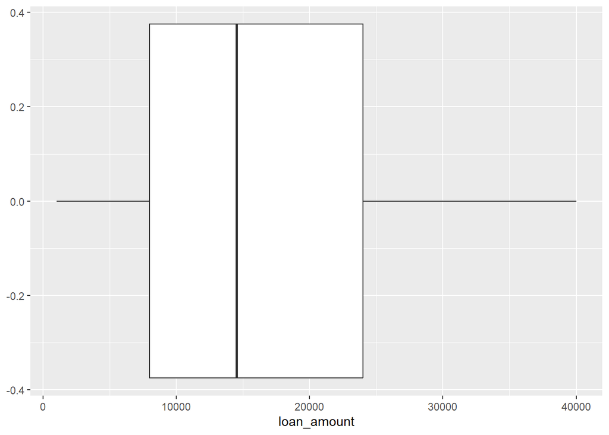

```r
ggplot(loans, aes(x = loan_amount)) +
  geom_boxplot()
```

### Customizing Boxplots

#### Adding Labels and titles

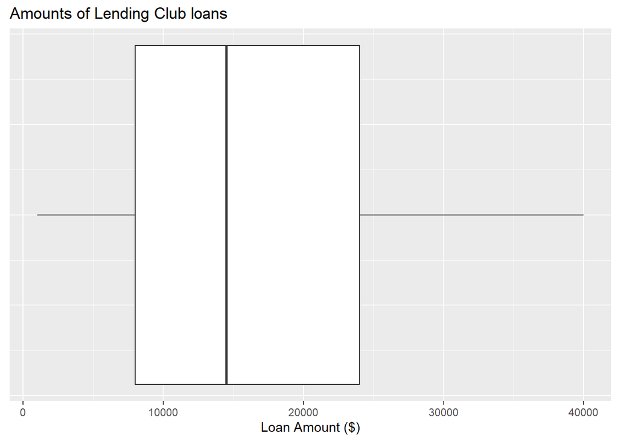

```r
ggplot(loans, aes(x = loan_amount)) +
  geom_boxplot() +
  labs(
    x = "Loan Amount ($)",
    y = NULL,
    title = "Amounts of Lending Club loans"
  ) +
  theme(
    axis.ticks.y = element_blank(),
    axis.text.y = element_blank()
  )
```

Just like a histogram, to change the color of the boxplot we can use the arguments `color` and `fill` within the `geom_boxplot` function.

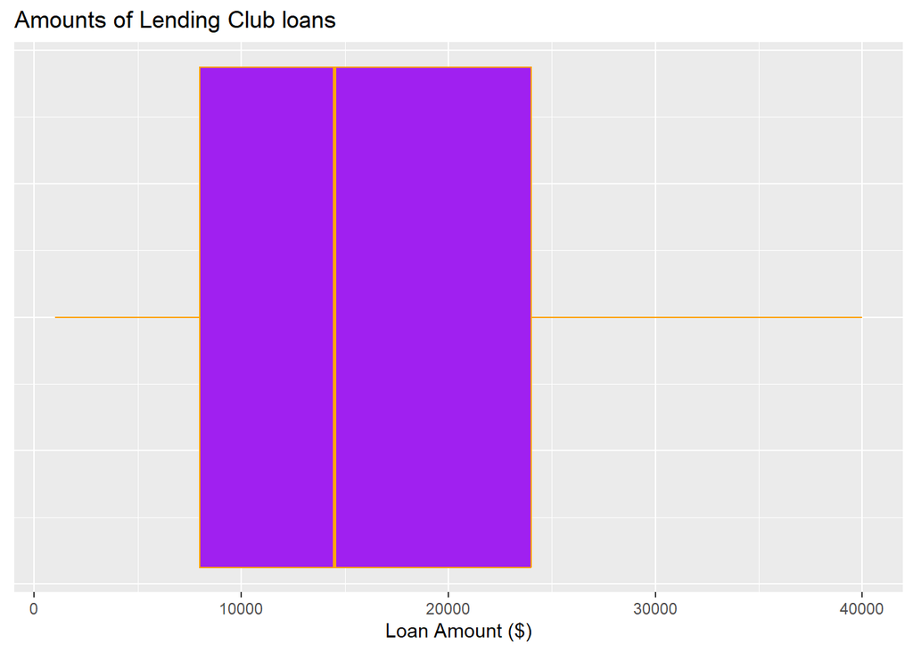

```r
ggplot(loans, aes(x = loan_amount)) +
  geom_boxplot(color="orange", fill="purple") +
  labs(
    x = "Loan Amount ($)",
    y = NULL,
    title = "Amounts of Lending Club loans"
  ) +
  theme(
    axis.ticks.y = element_blank(),
    axis.text.y = element_blank()
  )
```